# assignment_01

DIANA LIN

Updated 2020-03-03

## Assignment 01

Below are 6 exercises to help you practice vectorizing for-loops, and converting for-loops into vectorized expressions using `purrr` functions. This assignment was designed to be completed in about 60 minutes and is deliberately designed to be shorter to accommodate the team project.

```r
library(tidyverse)
mtcars_original <- mtcars
```

### Task 1: Convert for-loop code to vectorized expressions using `purrr` functions

#### 1.1 - Below is sample code that computes the mean of every column in the `mtcars` dataset. Use the appropriate `purrr` function to vectorize this task.

```r
output <- vector("double", ncol(mtcars))
for (c in seq_along(mtcars)){
  output[[c]] <- mean(mtcars[[c]])
}
output
```

```
##  [1]  20.090625   6.187500 230.721875 146.687500   3.596563   3.217250
##  [7]  17.848750   0.437500   0.406250   3.687500   2.812500
```

Your solution to vectorize the code above (using a `purrr` function):

```r
# use map_dbl to return a double vector
output <- map_dbl(mtcars, mean)
unname(output) # unname to remove names in vector to match output above
```

```
##  [1]  20.090625   6.187500 230.721875 146.687500   3.596563   3.217250
##  [7]  17.848750   0.437500   0.406250   3.687500   2.812500
```

#### 1.2 - Below is sample code that divides the values in each column of the `mtcars` dataset by the maximum in that column. Use the appropriate `purrr` function to vectorize this task.

```r
for (c in seq_along(mtcars)){
  mtcars[[c]] <- mtcars[[c]] / max(mtcars[[c]], na.rm = TRUE)
}
head(mtcars)
```

```
##                         mpg  cyl      disp        hp      drat        wt
## Mazda RX4         0.6194690 0.75 0.3389831 0.3283582 0.7910751 0.4830383
## Mazda RX4 Wag     0.6194690 0.75 0.3389831 0.3283582 0.7910751 0.5300516
## Datsun 710        0.6725664 0.50 0.2288136 0.2776119 0.7809331 0.4277286
## Hornet 4 Drive    0.6312684 0.75 0.5466102 0.3283582 0.6247465 0.5927360
## Hornet Sportabout 0.5516224 1.00 0.7627119 0.5223881 0.6389452 0.6342183
## Valiant           0.5339233 0.75 0.4766949 0.3134328 0.5598377 0.6379056
##                        qsec vs am gear  carb
## Mazda RX4         0.7187773  0  1  0.8 0.500
## Mazda RX4 Wag     0.7432314  0  1  0.8 0.500
## Datsun 710        0.8126638  1  1  0.8 0.125
## Hornet 4 Drive    0.8489083  1  0  0.6 0.125
## Hornet Sportabout 0.7432314  0  0  0.6 0.250
## Valiant           0.8829694  1  0  0.6 0.125
```

Your solution to vectorize the code above (using a `purrr` function):

```r
output <- as.data.frame(map_dfc(mtcars, function(df) df <- df / max(df, na.rm = TRUE))) # convert to data frame because row names are now allowed on a tibble
rownames(output) <- rownames(mtcars) # add rownames so it looks like it does in the above chunk output
head(output) # head to reduce output as above
```

```
##                         mpg  cyl      disp        hp      drat        wt
## Mazda RX4         0.6194690 0.75 0.3389831 0.3283582 0.7910751 0.4830383
## Mazda RX4 Wag     0.6194690 0.75 0.3389831 0.3283582 0.7910751 0.5300516
## Datsun 710        0.6725664 0.50 0.2288136 0.2776119 0.7809331 0.4277286
## Hornet 4 Drive    0.6312684 0.75 0.5466102 0.3283582 0.6247465 0.5927360
## Hornet Sportabout 0.5516224 1.00 0.7627119 0.5223881 0.6389452 0.6342183
## Valiant           0.5339233 0.75 0.4766949 0.3134328 0.5598377 0.6379056
##                        qsec vs am gear  carb
## Mazda RX4         0.7187773  0  1  0.8 0.500
## Mazda RX4 Wag     0.7432314  0  1  0.8 0.500
## Datsun 710        0.8126638  1  1  0.8 0.125
## Hornet 4 Drive    0.8489083  1  0  0.6 0.125
## Hornet Sportabout 0.7432314  0  0  0.6 0.250
## Valiant           0.8829694  1  0  0.6 0.125
```

#### 1.3 - Below is sample code that creates a ggplot with fuel efficiency on the x-axis and horsepower on the y-axis for three cylinder levels (4, 6, 8). Use the appropriate `purrr` function to vectorize this task.

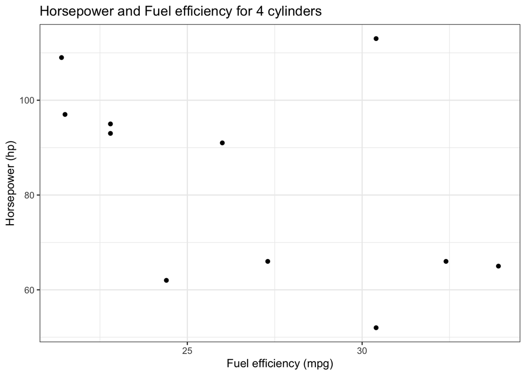

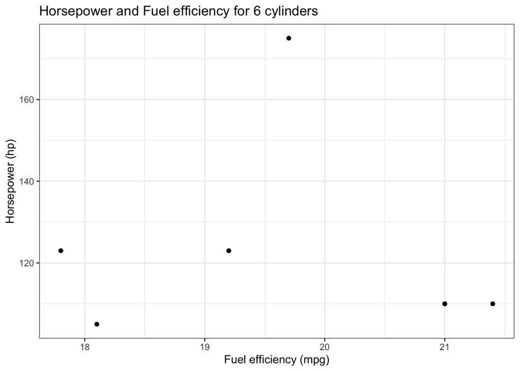

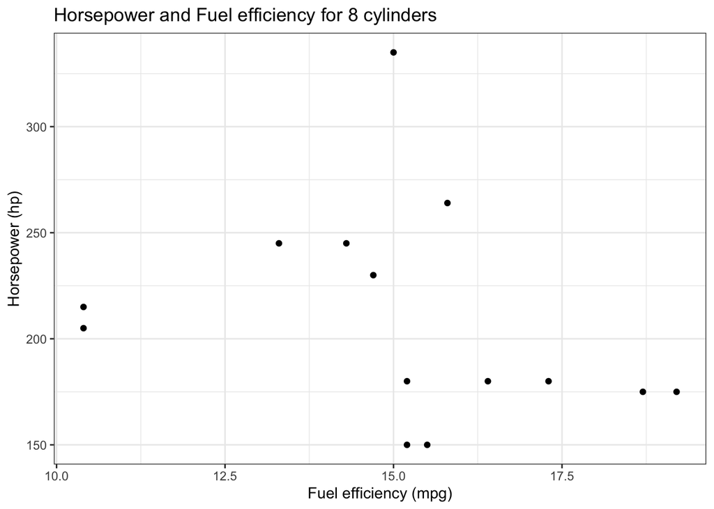

```r
cylinders <- sort(unique(mtcars_original[['cyl']]))
plots <- vector("list",length(cylinders))

for (d in 1:length(cylinders)){
  plots[[d]] <- mtcars_original %>%
    filter(cyl == cylinders[d]) %>%
    ggplot() +
    theme_bw() +
    geom_point(aes(x = mpg, y = hp) ) +
    labs(x = 'Fuel efficiency (mpg)',
         y = 'Horsepower (hp)') +
    ggtitle(glue::glue("Horsepower and Fuel efficiency for ", cylinders[d], " cylinders"))
}
plots
```

Your solution to vectorize the code above (using a `purrr` function):

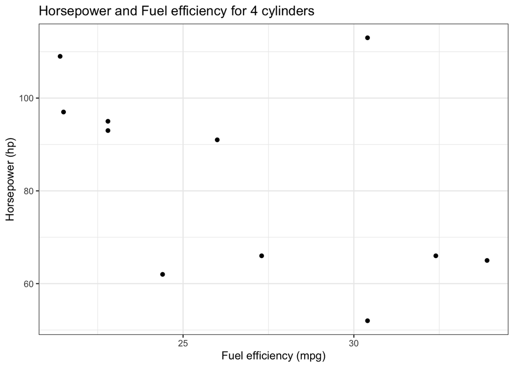

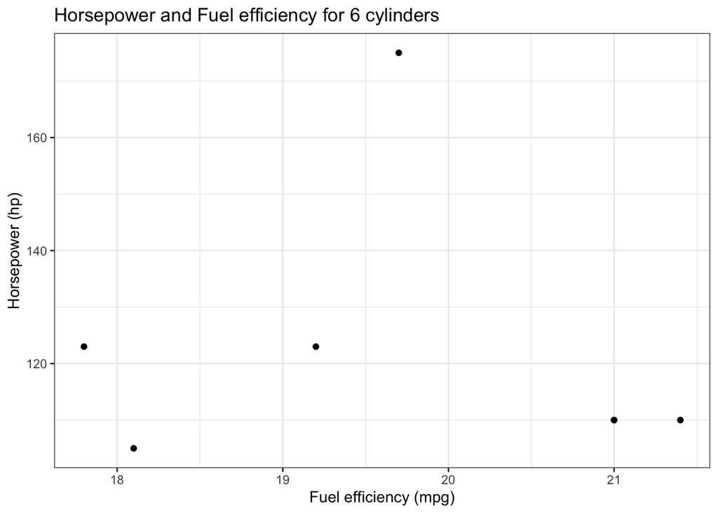

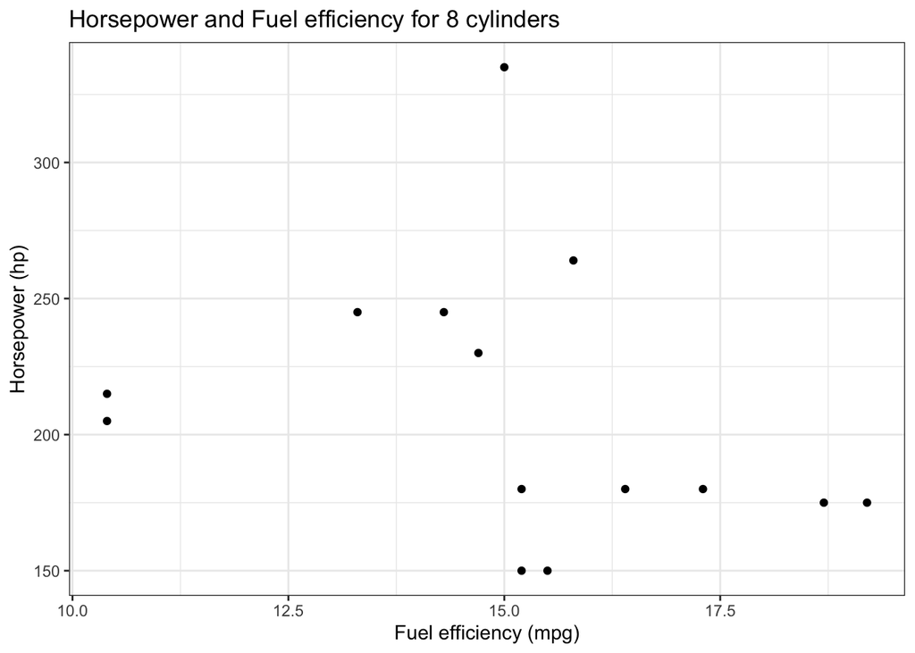

```r
# get cylinder vector (as above)
cylinders <- sort(unique(mtcars_original[['cyl']]))

# use function(x) to customize dplyr/ggplot combination of functions
plots <-
  map(cylinders, function(x)
    mtcars_original %>% filter(cyl == x) %>% ggplot() +
      theme_bw() +
      geom_point(aes(x = mpg, y = hp)) +
      labs(x = 'Fuel efficiency (mpg)',
           y = 'Horsepower (hp)') +
      ggtitle(glue::glue(
        "Horsepower and Fuel efficiency for ", x, " cylinders"
      )))

plots
```

### Task 2: Convert vectorized expressions into one that uses for-loops

#### 2.1 - Below is sample code that computes the number of unique values in each column of `mtcars` in a vectorized way. Turn this vectorized expression into one that uses for-loop(s) that reproduces the output (numbers should be the same, the format can be different).

```r
map(mtcars_original, unique) %>%
  map_dbl(length)
```

```
##  mpg  cyl disp   hp drat   wt qsec   vs   am gear carb
##   25    3   27   22   22   29   30    2    2    3    6
```

Your solution to “un-vectorize” the code above using for-loops:

```r
# allot memory for output
vectorized <- vector("double",length(mtcars_original))

# iterate through the columns, unique and then get length
for (i in seq_along(mtcars_original)) {
  vectorized[[i]] <- unique(mtcars_original[[i]]) %>%
    length()
}
names(vectorized) <- names(mtcars_original)
vectorized
```

```
##  mpg  cyl disp   hp drat   wt qsec   vs   am gear carb
##   25    3   27   22   22   29   30    2    2    3    6
```

#### 2.2 - Below is sample code that takes input from various columns in the `diamonds` dataset and outputs a string containing information from the input. Turn this vectorized expression into one that uses for-loop(s) that reproduces the output (numbers should be the same, the format can be different).

*Hint:* Note the use of `pmap_chr` to iterate over three columns (diamond number, price and carat).

```r
dmonds <- diamonds %>%
  slice(1:4)

list_of_things <- list(seq(nrow(dmonds)), dmonds$price, dmonds$carat)
output <- pmap_chr( list_of_things,
                   ~paste0("Diamond #", ..1 ,
                           " sold for $",..2,
                           " and was ",..3, " carats"))
output
```

```
## [1] "Diamond #1 sold for $326 and was 0.23 carats"
## [2] "Diamond #2 sold for $326 and was 0.21 carats"
## [3] "Diamond #3 sold for $327 and was 0.23 carats"
## [4] "Diamond #4 sold for $334 and was 0.29 carats"
```

Your solution to “un-vectorize” the code above using for-loops:

```r
library(glue)
# add solution here
dmonds <- diamonds %>%
  slice(1:4)

# allot the memory for output
output <- vector("character", nrow(dmonds))

# get the vectors to iterate through
num_diamonds <- seq(nrow(dmonds))
price_diamonds <- dmonds$price
carat_diamonds <- dmonds$carat

# iterate through all three using the same index i for each vector
for (i in seq_along(seq(nrow(dmonds)))) {
  output[[i]] <- glue("Diamond #{num_diamonds[i]} sold for ${price_diamonds[i]} and was {carat_diamonds[i]} carats")
}

output
```

```
## [1] "Diamond #1 sold for $326 and was 0.23 carats"
## [2] "Diamond #2 sold for $326 and was 0.21 carats"
## [3] "Diamond #3 sold for $327 and was 0.23 carats"
## [4] "Diamond #4 sold for $334 and was 0.29 carats"
```

#### 2.3 - Below is sample code that splits the iris dataset into three species, and saves each dataframe as a separate file. Turn this vectorized expression into one that uses a for-loop that reproduces the output.

*Hint 1*: `map2(x, y, f)` is the same as `pmap(list(x, y), f)`

*Hint 2*: Multiple files can be saved in a vectorized way using the`pmap` function. The [`nest` function](https://tidyr.tidyverse.org/reference/nest.html) is used to create a list-column of data frames for each species from the `iris` dataset.

```r
iris %>%
  nest(data = -Species) %>%
  pmap(~write_csv(.y, path = here::here(glue::glue(.x, ".csv"))))
```

```
## [[1]]
## # A tibble: 50 x 4
##    Sepal.Length Sepal.Width Petal.Length Petal.Width
##           <dbl>       <dbl>        <dbl>       <dbl>
##  1          5.1         3.5          1.4         0.2
##  2          4.9         3            1.4         0.2
##  3          4.7         3.2          1.3         0.2
##  4          4.6         3.1          1.5         0.2
##  5          5           3.6          1.4         0.2
##  6          5.4         3.9          1.7         0.4
##  7          4.6         3.4          1.4         0.3
##  8          5           3.4          1.5         0.2
##  9          4.4         2.9          1.4         0.2
## 10          4.9         3.1          1.5         0.1
## # … with 40 more rows
##
## [[2]]
## # A tibble: 50 x 4
##    Sepal.Length Sepal.Width Petal.Length Petal.Width
##           <dbl>       <dbl>        <dbl>       <dbl>
##  1          7           3.2          4.7         1.4
##  2          6.4         3.2          4.5         1.5
##  3          6.9         3.1          4.9         1.5
##  4          5.5         2.3          4           1.3
##  5          6.5         2.8          4.6         1.5
##  6          5.7         2.8          4.5         1.3
##  7          6.3         3.3          4.7         1.6
##  8          4.9         2.4          3.3         1
##  9          6.6         2.9          4.6         1.3
## 10          5.2         2.7          3.9         1.4
## # … with 40 more rows
##
## [[3]]
## # A tibble: 50 x 4
##    Sepal.Length Sepal.Width Petal.Length Petal.Width
##           <dbl>       <dbl>        <dbl>       <dbl>
##  1          6.3         3.3          6           2.5
##  2          5.8         2.7          5.1         1.9
##  3          7.1         3            5.9         2.1
##  4          6.3         2.9          5.6         1.8
##  5          6.5         3            5.8         2.2
##  6          7.6         3            6.6         2.1
##  7          4.9         2.5          4.5         1.7
##  8          7.3         2.9          6.3         1.8
##  9          6.7         2.5          5.8         1.8
## 10          7.2         3.6          6.1         2.5
## # … with 40 more rows
```

Your solution to “un-vectorize” the code above using for-loops:

```r
# get the three species
species <- sort(unique(iris$Species))

# allot the memory
dfs <- vector("list", length(species))

# iterate through each species and write the csv and put into dfs
for (i in seq_along(species)) {
  dfs[[i]] <- iris %>%
    filter(Species == species[i]) %>% # filter for specific species
    select(-Species) %>% # remove species from the data frame
    as_tibble() # convert to tibble as above output was a tibble

  write_csv(dfs[[i]], path = here::here(paste0(i, ".csv"))) # write to current working directory using the same naming convention as above
}

dfs # print tibble to see
```

```
## [[1]]
## # A tibble: 50 x 4
##    Sepal.Length Sepal.Width Petal.Length Petal.Width
##           <dbl>       <dbl>        <dbl>       <dbl>
##  1          5.1         3.5          1.4         0.2
##  2          4.9         3            1.4         0.2
##  3          4.7         3.2          1.3         0.2
##  4          4.6         3.1          1.5         0.2
##  5          5           3.6          1.4         0.2
##  6          5.4         3.9          1.7         0.4
##  7          4.6         3.4          1.4         0.3
##  8          5           3.4          1.5         0.2
##  9          4.4         2.9          1.4         0.2
## 10          4.9         3.1          1.5         0.1
## # … with 40 more rows
##
## [[2]]
## # A tibble: 50 x 4
##    Sepal.Length Sepal.Width Petal.Length Petal.Width
##           <dbl>       <dbl>        <dbl>       <dbl>
##  1          7           3.2          4.7         1.4
##  2          6.4         3.2          4.5         1.5
##  3          6.9         3.1          4.9         1.5
##  4          5.5         2.3          4           1.3
##  5          6.5         2.8          4.6         1.5
##  6          5.7         2.8          4.5         1.3
##  7          6.3         3.3          4.7         1.6
##  8          4.9         2.4          3.3         1
##  9          6.6         2.9          4.6         1.3
## 10          5.2         2.7          3.9         1.4
## # … with 40 more rows
##
## [[3]]
## # A tibble: 50 x 4
##    Sepal.Length Sepal.Width Petal.Length Petal.Width
##           <dbl>       <dbl>        <dbl>       <dbl>
##  1          6.3         3.3          6           2.5
##  2          5.8         2.7          5.1         1.9
##  3          7.1         3            5.9         2.1
##  4          6.3         2.9          5.6         1.8
##  5          6.5         3            5.8         2.2
##  6          7.6         3            6.6         2.1
##  7          4.9         2.5          4.5         1.7
##  8          7.3         2.9          6.3         1.8
##  9          6.7         2.5          5.8         1.8
## 10          7.2         3.6          6.1         2.5
## # … with 40 more rows
```

## Additional Resources

1. Chapter 21 of [R for Data Science](https://r4ds.had.co.nz/iteration.html).
2. [Learn to purr](http://www.rebeccabarter.com/blog/2019-08-19_purrr/) blog post.
3. Chapter 9 of [Advanced R for Data Science](https://adv-r.hadley.nz/functionals.html).